# Applied Data Science

Data Wrangling  
18.03.2019

### Disclaimer

Builds on top of the The R Bootcamp sliide deck:

https://therbootcamp.github.io/BaselRBootcamp_2018April/_sessions/D2S1_Wrangling/Wrangling.html#1

### What is Wrangling

Transform

- Adding new columns
- Combining columns
- Splitting columns

Organise

- Moving data between columns and rows
- Merging several dataframes
- Sorting data by columns

Aggregation

- Aggregate data according to variables
- Summarizing data across groups

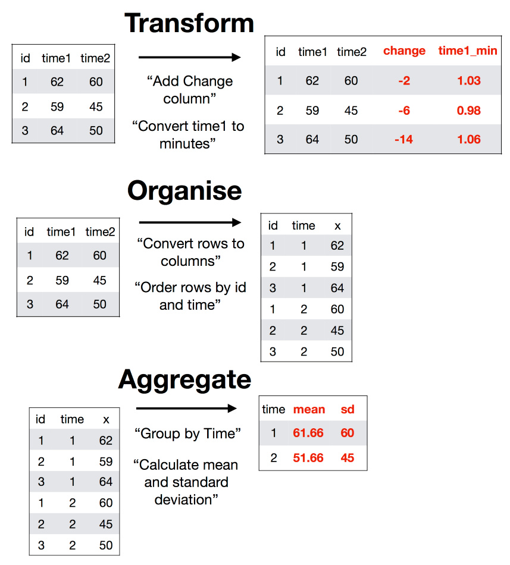

### How is Wrangling easily done in R?

Answer: `dplyr` Anytime you want to transform, organize, or aggregate data, use dplyr

[figure not shown]

[figure not shown]

### dplyr in a nutshell

dplyr combines

- Enhanced data frame objects (`tibble`)
- Powerful functions that manipulate data objects
- The pipe operator `%>%` that strings together objects and verbs

to create a very approachable and intuitive way to data wrangling operations

- dplyr is meant to be sequential and works like language: Take data trial, then do Y, then do Z, …

## The pipe

Standard way to call a function

```r
FUN(arg)
```

Using the pipe to call a function

```r
arg %>% FUN()
```

```r
library(tidyverse)
ToothGrowth$len %>% mean()
```

```
[1] 18.81333
```

- You can call all dplyr functions directly without the pipe `%>%`
- The advantage of the pipe `%>%` becomes evident when running multiple processing steps and we hence recommend using it throughout

### Organisation Functions

| Function | Description |
| --- | --- |
| `select()` | Select specific columns |
| `arrange()` | Sort rows |
| `filter()` | Select specific rows |

- Keep columns with `select(COL1, COL2, ...)`
- Remove columns with `select(-COL1, -COL2, ...)`

```r
head(diamonds, 2)
```

```
# A tibble: 2 x 10
  carat cut     color clarity depth table price     x     y     z
  <dbl> <ord>   <ord> <ord>   <dbl> <dbl> <int> <dbl> <dbl> <dbl>
1  0.23 Ideal   E     SI2      61.5    55   326  3.95  3.98  2.43
2  0.21 Premium E     SI1      59.8    61   326  3.89  3.84  2.31
```

```r
diamonds %>%
  select(carat, cut) %>%
  head(2)
```

```
# A tibble: 2 x 2
  carat cut
  <dbl> <ord>
1  0.23 Ideal
2  0.21 Premium
```

```r
diamonds %>% select(carat, cut) %>%
  select(-cut) %>% head(2)
```

```
# A tibble: 2 x 1
  carat
  <dbl>
1  0.23
2  0.21
```

### Organisation Functions

| Function | Description |
| --- | --- |
| `select()` | Select specific columns |
| `arrange()` | Sort rows |
| `filter()` | Select specific rows |

- The `arrange()` function is used to sort (aka, arrange) rows of a dataframe
- You can sort by as many conditions as you want
- To sort in descending order, use `desc()` or negated values

```r
diamonds %>%
  select(carat, cut) %>%
  arrange(carat) %>%
  head(2)
```

```
# A tibble: 2 x 2
  carat cut
  <dbl> <ord>
1   0.2 Premium
2   0.2 Premium
```

```r
diamonds %>%
  select(carat, cut) %>%
  arrange(-carat) %>%
  head(2)
```

```
# A tibble: 2 x 2
  carat cut
  <dbl> <ord>
1  5.01 Fair
2  4.5  Fair
```

### Organisation Functions

| Function | Description |
| --- | --- |
| `select()` | Select specific columns |
| `arrange()` | Sort rows |
| `filter()` | Select specific rows |

- The `filter()` function is used to select specific rows
- For complex conditions, chain multiple logical comparison operators `(==, !=, <, >, <=, >=, &, |)`

```r
diamonds %>%
  select(carat, cut) %>%
  arrange(carat) %>%
  filter(carat > 1) %>%
  head(2)
```

```
# A tibble: 2 x 2
  carat cut
  <dbl> <ord>
1  1.01 Premium
2  1.01 Fair
```

```r
diamonds %>%
  select(carat, cut) %>%
  arrange(-carat) %>%
  filter(carat <4) %>%
  head(2)
```

```
# A tibble: 2 x 2
  carat cut
  <dbl> <ord>
1  3.67 Premium
2  3.65 Fair
```

### Transformation Functions

| Function | Description |
| --- | --- |
| `rename()` | Change column names |
| `mutate()` | Create a new column from existing columns |
| `left_join()` | Combine multiple dataframes |

- Change column names with `rename()`
- New = Old

```r
diamonds %>%
  select(carat, cut) %>%
  head(2)
```

```
# A tibble: 2 x 2
  carat cut
  <dbl> <ord>
1  0.23 Ideal
2  0.21 Premium
```

```r
diamonds %>%
  select(carat, cut) %>%
  rename(weight = carat) %>%
  head(2)
```

```
# A tibble: 2 x 2
  weight cut
   <dbl> <ord>
1   0.23 Ideal
2   0.21 Premium
```

### Transformation Functions

| Function | Description |
| --- | --- |
| `rename()` | Change column names |
| `mutate()` | Create a new column from existing columns |
| `left_join()` | Combine multiple dataframes |

- Add new columns with `mutate()`

```r
diamonds %>%
  select(x, y, z, carat) %>%
  mutate(volume = x * y * z) %>%
  arrange(-volume) %>%
  head(5)
```

```
# A tibble: 5 x 5
      x     y     z carat volume
  <dbl> <dbl> <dbl> <dbl>  <dbl>
1  8.09 58.9   8.06  2     3841.
2  5.12  5.15 31.8   0.51   839.
3  5.15 31.8   5.12  0.51   839.
4 10.7  10.5   6.98  5.01   790.
5 10.2  10.2   6.72  4.5    698.
```

### Transformation Functions

| Function | Description |
| --- | --- |
| `rename()` | Change column names |
| `mutate()` | Create a new column from existing columns |
| `left_join()` | Combine multiple dataframes |

- Use `left_join()` to combine data from 2 dataframes
- If no `by` argument is specified all identically named columns are used as keys

```r
library(nycflights13)
colnames(planes)
```

```
[1] "tailnum"      "year"         "type"         "manufacturer"
[5] "model"        "engines"      "seats"        "speed"
[9] "engine"
```

```r
colnames(flights)
```

```
 [1] "year"           "month"          "day"            "dep_time"
 [5] "sched_dep_time" "dep_delay"      "arr_time"       "sched_arr_time"
 [9] "arr_delay"      "carrier"        "flight"         "tailnum"
[13] "origin"         "dest"           "air_time"       "distance"
[17] "hour"           "minute"         "time_hour"
```

### Transformation Functions

| Function | Description |
| --- | --- |
| `rename()` | Change column names |
| `mutate()` | Create a new column from existing columns |
| `left_join()` | Combine multiple dataframes |

- Use `left_join()` to combine data from 2 dataframes
- If no `by` argument is specified all identically named columns are used as keys

```r
flights %>%
  select(flight, tailnum) %>%
  left_join(planes) %>%
  colnames()
```

```
 [1] "flight"       "tailnum"      "year"         "type"
 [5] "manufacturer" "model"        "engines"      "seats"
 [9] "speed"        "engine"
```

```r
flights %>%
  select(flight, tailnum) %>%
  left_join(planes, by = "tailnum") %>%
  colnames()
```

```
 [1] "flight"       "tailnum"      "year"         "type"
 [5] "manufacturer" "model"        "engines"      "seats"
 [9] "speed"        "engine"
```

### Aggregation Functions

| Function | Description |
| --- | --- |
| `group_by()` | Group data by levels of specific variables |
| `summarise()` | Calculate summary statistics |

- `group_by()` is used to annotate data with respect to underlying groups
- You can group by as many variables as you wish
- You will not see any changes to the data until you use `summarise()`

```r
diamonds %>%
  group_by(cut)
```

```
# A tibble: 53,940 x 10
# Groups:   cut [5]
   carat cut       color clarity depth table price     x     y     z
   <dbl> <ord>     <ord> <ord>   <dbl> <dbl> <int> <dbl> <dbl> <dbl>
 1 0.23  Ideal     E     SI2      61.5    55   326  3.95  3.98  2.43
 2 0.21  Premium   E     SI1      59.8    61   326  3.89  3.84  2.31
 3 0.23  Good      E     VS1      56.9    65   327  4.05  4.07  2.31
 4 0.290 Premium   I     VS2      62.4    58   334  4.2   4.23  2.63
 5 0.31  Good      J     SI2      63.3    58   335  4.34  4.35  2.75
 6 0.24  Very Good J     VVS2     62.8    57   336  3.94  3.96  2.48
 7 0.24  Very Good I     VVS1     62.3    57   336  3.95  3.98  2.47
 8 0.26  Very Good H     SI1      61.9    55   337  4.07  4.11  2.53
 9 0.22  Fair      E     VS2      65.1    61   337  3.87  3.78  2.49
10 0.23  Very Good H     VS1      59.4    61   338  4     4.05  2.39
# ... with 53,930 more rows
```

### Aggregation Functions

| Function | Description |
| --- | --- |
| `group_by()` | Group data by levels of specific variables |
| `summarise()` | Calculate summary statistics |

- `summarise()` is used to summarise data from groups
- Works similar to `mutate()` to create new variables, but with summary functions

```r
diamonds %>%
  group_by(cut, clarity) %>%
  summarise(meanPrice = mean(price),
            maxPrice = max(price),
            meanWeight = mean(carat)) %>%
  mutate(meanPricePerCarat = meanPrice / meanWeight)
```

```
# A tibble: 40 x 6
# Groups:   cut [5]
   cut   clarity meanPrice maxPrice meanWeight meanPricePerCarat
   <ord> <ord>       <dbl>    <dbl>      <dbl>             <dbl>
 1 Fair  I1          3704.    18531      1.36              2721.
 2 Fair  SI2         5174.    18308      1.20              4298.
 3 Fair  SI1         4208.    18574      0.965             4363.
 4 Fair  VS2         4175.    18565      0.885             4716.
 5 Fair  VS1         4165.    17995      0.880             4734.
 6 Fair  VVS2        3350.    16364      0.692             4844.
 7 Fair  VVS1        3871.    12648      0.665             5824.
 8 Fair  IF          1912.     3205      0.474             4031.
 9 Good  I1          3597.    11548      1.20              2990.
10 Good  SI2         4580.    18788      1.04              4424.
# ... with 30 more rows
```

### Size of the function output depends on operation

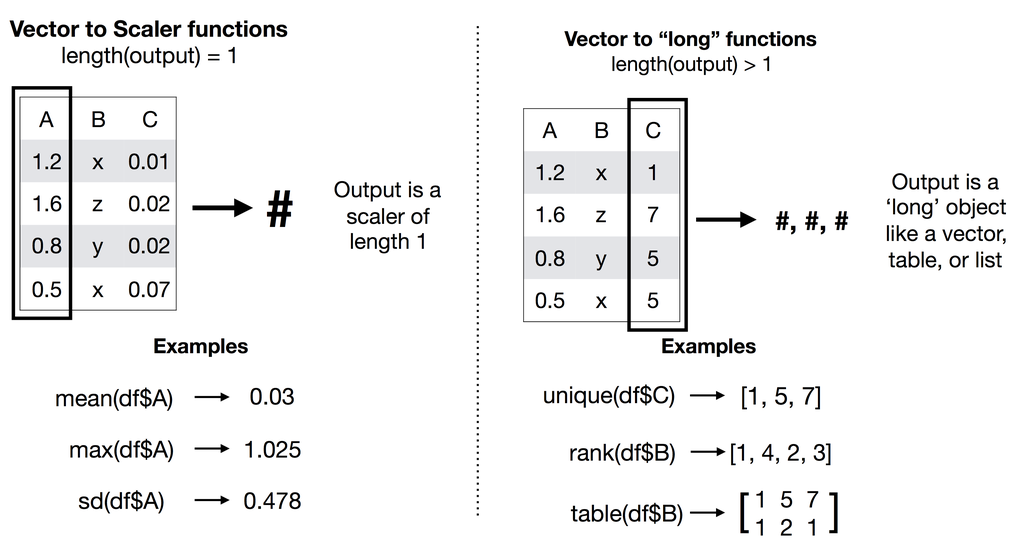

### Some helpful operations

## Summary Functions

- Vetor to Scaler

| Function | action |
| --- | --- |
| `min()`, `max()` | Minimum, maximum |
| `mean()`, `median()` | Mean, Median |
| `sd()` | Standard deviation |
| `sum()` | Sum |
| `n()` | Number of cases |

- Vector to Vector

| Function | action |
| --- | --- |
| `unique(x)` | What are the unique values of x? |
| `table(x)` | How many are there of each unique value in x? |
| `rank(x)` | What is the rank order of values in x? |

## Data frame operations

| verb | action | example |
| --- | --- | --- |
| `sample_n()` | Select a random sample of n rows | sample_n(10) |
| `sample_frac()` | Select a random fraction of rows | sample_frac(.20) |
| `first()`, `last()` | Give the first (or last) observation | first(), last() |

### Programming Task

Use the `ChickWeight` dataframe

- Add a column called weight_d_time that is weight divided by time
- Calculate the mean weight and time for each diet.
- Add a column called weight_d_time that is weight divided by time AND time_d that is time in days
- Create a new variable Diet_name which shows Diet in text format (1 is fruit, 2 is vegetables, 3 is meat, 4 is grain). The `case_when()` function is helpful for this task.
- For each time period less than 10, calculate the mean weight
- For each Diet, calculate the mean weight, maximum time, and the number of chicks on each diet
- Give me a random sample of 10 rows from the ChickWeight dataframe, but only show me the values for Chick and weight (`sample_n`)

```r
diamonds %>%
  select(carat) %>%
  mutate(weight_qualitative = case_when(
            carat > 4 ~ "YUUUUGGGE",
            carat <= 4 ~ "LITTTTTLEE")
  ) %>%
  filter(carat > 3.95)
```

```
# A tibble: 6 x 2
  carat weight_qualitative
  <dbl> <chr>
1  4.01 YUUUUGGGE
2  4.01 YUUUUGGGE
3  4    LITTTTTLEE
4  4.13 YUUUUGGGE
5  5.01 YUUUUGGGE
6  4.5  YUUUUGGGE
```